# Project 4 - Andrew Susanto

## Background and Context

AllLife Bank is a US bank that has a growing customer base. The majority of these customers are liability customers (depositors) with varying sizes of deposits. The number of customers who are also borrowers (asset customers) is quite small, and the bank is interested in expanding this base rapidly to bring in more loan business and in the process, earn more through the interest on loans. In particular, the management wants to explore ways of converting its liability customers to personal loan customers (while retaining them as depositors).

A campaign that the bank ran last year for liability customers showed a healthy conversion rate of over 9% success. This has encouraged the retail marketing department to devise campaigns with better target marketing to increase the success ratio.

You as a Data scientist at AllLife bank have to build a model that will help the marketing department to identify the potential customers who have a higher probability of purchasing the loan.

## Objective

To predict whether a liability customer will buy a personal loan or not. Which variables are most significant. Which segment of customers should be targeted more.

## Data Dictionary

ID: Customer ID

Age: Customer’s age in completed years

Experience: #years of professional experience

Income: Annual income of the customer (in thousand dollars)

ZIP Code: Home Address ZIP code.

Family: the Family size of the customer

CCAvg: Average spending on credit cards per month (in thousand dollars)

Education: Education Level. 1: Undergrad; 2: Graduate;3: Advanced/Professional

Mortgage: Value of house mortgage if any. (in thousand dollars)

Personal_Loan: Did this customer accept the personal loan offered in the last campaign?

Securities_Account: Does the customer have securities account with the bank?

CD_Account: Does the customer have a certificate of deposit (CD) account with the bank?

Online: Do customers use internet banking facilities?

CreditCard: Does the customer use a credit card issued by any other Bank (excluding All life Bank)?

## Library Import & Data Checking

```python
#importing of required libraries

import pandas as pd
import numpy as np
from sklearn import metrics
import matplotlib.pyplot as plt
%matplotlib inline
import seaborn as sns
from sklearn.model_selection import train_test_split
from sklearn.tree import DecisionTreeClassifier
from sklearn import tree

#import library to ignore warnings

import warnings
warnings.filterwarnings('ignore')
```

```python
#importing data

df = pd.read_csv('Loan_Modelling.csv')
```

```python
#checking of data

df.head()
```

|  | ID | Age | Experience | Income | ZIPCode | Family | CCAvg | Education | Mortgage | Personal_Loan | Securities_Account | CD_Account | Online | CreditCard |
| --- | --- | --- | --- | --- | --- | --- | --- | --- | --- | --- | --- | --- | --- | --- |
| 0 | 1 | 25 | 1 | 49 | 91107 | 4 | 1.6 | 1 | 0 | 0 | 1 | 0 | 0 | 0 |
| 1 | 2 | 45 | 19 | 34 | 90089 | 3 | 1.5 | 1 | 0 | 0 | 1 | 0 | 0 | 0 |
| 2 | 3 | 39 | 15 | 11 | 94720 | 1 | 1.0 | 1 | 0 | 0 | 0 | 0 | 0 | 0 |
| 3 | 4 | 35 | 9 | 100 | 94112 | 1 | 2.7 | 2 | 0 | 0 | 0 | 0 | 0 | 0 |
| 4 | 5 | 35 | 8 | 45 | 91330 | 4 | 1.0 | 2 | 0 | 0 | 0 | 0 | 0 | 1 |

```python
df.tail()
```

|  | ID | Age | Experience | Income | ZIPCode | Family | CCAvg | Education | Mortgage | Personal_Loan | Securities_Account | CD_Account | Online | CreditCard |
| --- | --- | --- | --- | --- | --- | --- | --- | --- | --- | --- | --- | --- | --- | --- |
| 4995 | 4996 | 29 | 3 | 40 | 92697 | 1 | 1.9 | 3 | 0 | 0 | 0 | 0 | 1 | 0 |
| 4996 | 4997 | 30 | 4 | 15 | 92037 | 4 | 0.4 | 1 | 85 | 0 | 0 | 0 | 1 | 0 |
| 4997 | 4998 | 63 | 39 | 24 | 93023 | 2 | 0.3 | 3 | 0 | 0 | 0 | 0 | 0 | 0 |
| 4998 | 4999 | 65 | 40 | 49 | 90034 | 3 | 0.5 | 2 | 0 | 0 | 0 | 0 | 1 | 0 |
| 4999 | 5000 | 28 | 4 | 83 | 92612 | 3 | 0.8 | 1 | 0 | 0 | 0 | 0 | 1 | 1 |

```python
np.random.seed(1)
df.sample(n=10)
```

|  | ID | Age | Experience | Income | ZIPCode | Family | CCAvg | Education | Mortgage | Personal_Loan | Securities_Account | CD_Account | Online | CreditCard |
| --- | --- | --- | --- | --- | --- | --- | --- | --- | --- | --- | --- | --- | --- | --- |
| 2764 | 2765 | 31 | 5 | 84 | 91320 | 1 | 2.9 | 3 | 105 | 0 | 0 | 0 | 0 | 1 |
| 4767 | 4768 | 35 | 9 | 45 | 90639 | 3 | 0.9 | 1 | 101 | 0 | 1 | 0 | 0 | 0 |
| 3814 | 3815 | 34 | 9 | 35 | 94304 | 3 | 1.3 | 1 | 0 | 0 | 0 | 0 | 0 | 0 |
| 3499 | 3500 | 49 | 23 | 114 | 94550 | 1 | 0.3 | 1 | 286 | 0 | 0 | 0 | 1 | 0 |
| 2735 | 2736 | 36 | 12 | 70 | 92131 | 3 | 2.6 | 2 | 165 | 0 | 0 | 0 | 1 | 0 |
| 3922 | 3923 | 31 | 4 | 20 | 95616 | 4 | 1.5 | 2 | 0 | 0 | 0 | 0 | 1 | 0 |
| 2701 | 2702 | 50 | 26 | 55 | 94305 | 1 | 1.6 | 2 | 0 | 0 | 0 | 0 | 1 | 0 |
| 1179 | 1180 | 36 | 11 | 98 | 90291 | 3 | 1.2 | 3 | 0 | 0 | 1 | 0 | 0 | 1 |
| 932 | 933 | 51 | 27 | 112 | 94720 | 3 | 1.8 | 2 | 0 | 0 | 1 | 1 | 1 | 1 |
| 792 | 793 | 41 | 16 | 98 | 93117 | 1 | 4.0 | 3 | 0 | 0 | 0 | 0 | 0 | 1 |

```python
#checking data shape
df.shape
```

```
(5000, 14)
```

```python
#checking values of Personal_Loan
df['Personal_Loan'].value_counts()
```

```
0    4520
1     480
Name: Personal_Loan, dtype: int64
```

```python
#checking data info (types and non-null count)
df.info()
```

```
<class 'pandas.core.frame.DataFrame'>
RangeIndex: 5000 entries, 0 to 4999
Data columns (total 14 columns):
 #   Column              Non-Null Count  Dtype
---  ------              --------------  -----
 0   ID                  5000 non-null   int64
 1   Age                 5000 non-null   int64
 2   Experience          5000 non-null   int64
 3   Income              5000 non-null   int64
 4   ZIPCode             5000 non-null   int64
 5   Family              5000 non-null   int64
 6   CCAvg               5000 non-null   float64
 7   Education           5000 non-null   int64
 8   Mortgage            5000 non-null   int64
 9   Personal_Loan       5000 non-null   int64
 10  Securities_Account  5000 non-null   int64
 11  CD_Account          5000 non-null   int64
 12  Online              5000 non-null   int64
 13  CreditCard          5000 non-null   int64
dtypes: float64(1), int64(13)
memory usage: 547.0 KB
```

Using df.shape and df.info(), it can be seen that there are no null values for this data. The data type for the variables seems to be correct. However, the columns ID and ZIPCode does not seem to be relevant for data prediction, and hence need to be removed.

```python
#removal of ID and ZIPCode columns

df.drop('ID',axis = 1,inplace=True)
df.drop('ZIPCode',axis = 1,inplace=True)
```

```python
#checking if data has been removed

df.info()
```

```
<class 'pandas.core.frame.DataFrame'>
RangeIndex: 5000 entries, 0 to 4999
Data columns (total 12 columns):
 #   Column              Non-Null Count  Dtype
---  ------              --------------  -----
 0   Age                 5000 non-null   int64
 1   Experience          5000 non-null   int64
 2   Income              5000 non-null   int64
 3   Family              5000 non-null   int64
 4   CCAvg               5000 non-null   float64
 5   Education           5000 non-null   int64
 6   Mortgage            5000 non-null   int64
 7   Personal_Loan       5000 non-null   int64
 8   Securities_Account  5000 non-null   int64
 9   CD_Account          5000 non-null   int64
 10  Online              5000 non-null   int64
 11  CreditCard          5000 non-null   int64
dtypes: float64(1), int64(11)
memory usage: 468.9 KB
```

We'll further check on the data distribution using univariate and bivariate analysis.

## Univariate Analysis

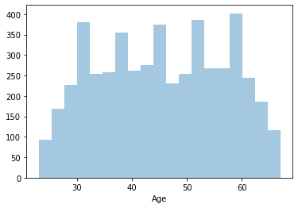

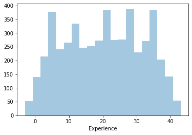

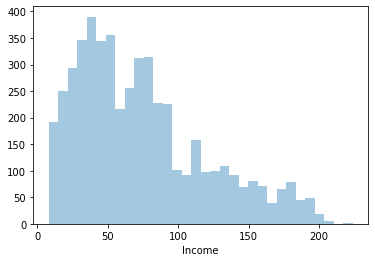

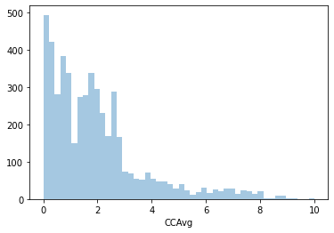

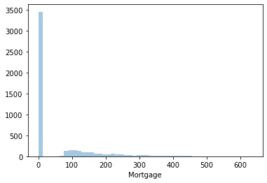

```python
#histogram creation for each variable

for col in ['Age','Experience','Income','CCAvg','Mortgage']:
    sns.distplot(df[col], kde = False)
    plt.show()
```

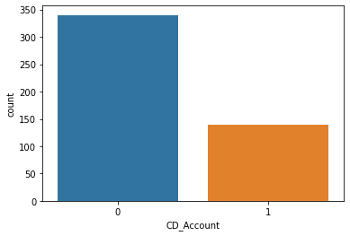

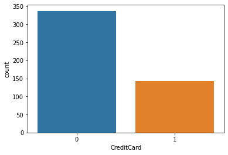

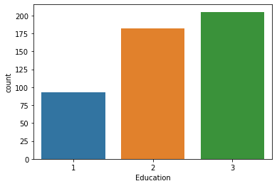

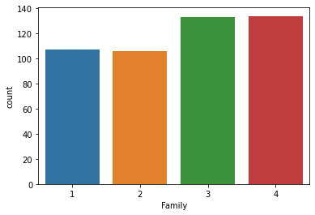

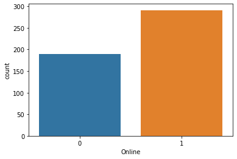

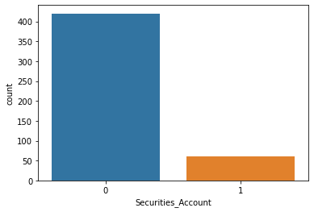

```python
#countplot for boolean integer variables

df['PLoanCat']=df['Personal_Loan'].astype('category')
PLoanTrue = df[df['Personal_Loan'] == 1]

for i in ['CD_Account','CreditCard','Education','Family','Online','Securities_Account']:
    sns.countplot(PLoanTrue[i])
    plt.show()
```

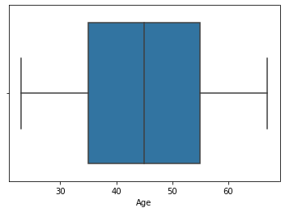

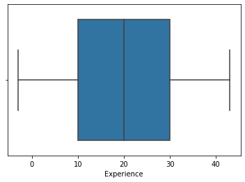

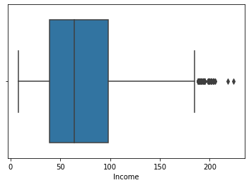

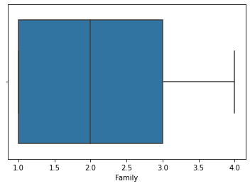

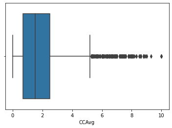

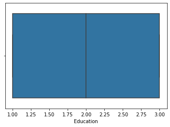

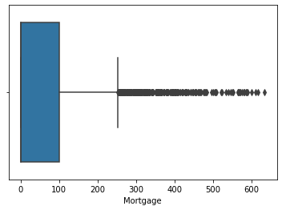

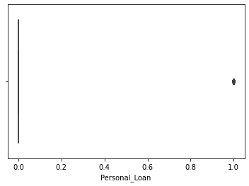

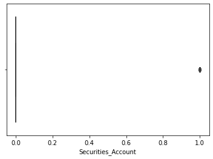

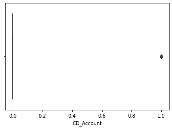

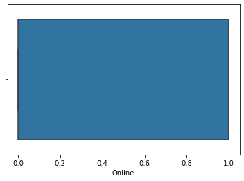

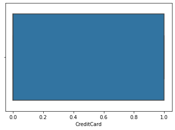

[1 more figures not shown]

```python
#boxplot creation for each variable

for col in df.columns:
    sns.boxplot(df[col])
    plt.show()
```

```python
#checking the statistics of the data

df.describe()
```

|  | Age | Experience | Income | Family | CCAvg | Education | Mortgage | Personal_Loan | Securities_Account | CD_Account | Online | CreditCard |
| --- | --- | --- | --- | --- | --- | --- | --- | --- | --- | --- | --- | --- |
| count | 5000.000000 | 5000.000000 | 5000.000000 | 5000.000000 | 5000.000000 | 5000.000000 | 5000.000000 | 5000.000000 | 5000.000000 | 5000.00000 | 5000.000000 | 5000.000000 |
| mean | 45.338400 | 20.104600 | 73.774200 | 2.396400 | 1.937938 | 1.881000 | 56.498800 | 0.096000 | 0.104400 | 0.06040 | 0.596800 | 0.294000 |
| std | 11.463166 | 11.467954 | 46.033729 | 1.147663 | 1.747659 | 0.839869 | 101.713802 | 0.294621 | 0.305809 | 0.23825 | 0.490589 | 0.455637 |
| min | 23.000000 | -3.000000 | 8.000000 | 1.000000 | 0.000000 | 1.000000 | 0.000000 | 0.000000 | 0.000000 | 0.00000 | 0.000000 | 0.000000 |
| 25% | 35.000000 | 10.000000 | 39.000000 | 1.000000 | 0.700000 | 1.000000 | 0.000000 | 0.000000 | 0.000000 | 0.00000 | 0.000000 | 0.000000 |
| 50% | 45.000000 | 20.000000 | 64.000000 | 2.000000 | 1.500000 | 2.000000 | 0.000000 | 0.000000 | 0.000000 | 0.00000 | 1.000000 | 0.000000 |
| 75% | 55.000000 | 30.000000 | 98.000000 | 3.000000 | 2.500000 | 3.000000 | 101.000000 | 0.000000 | 0.000000 | 0.00000 | 1.000000 | 1.000000 |
| max | 67.000000 | 43.000000 | 224.000000 | 4.000000 | 10.000000 | 3.000000 | 635.000000 | 1.000000 | 1.000000 | 1.00000 | 1.000000 | 1.000000 |

From univariate analysis above, we can conclude that:

```python
#checking how many rows that need to be removed
df[df['Experience']<0].shape
```

```
(52, 13)
```

```python
#removing erroneous experience data
df = df.drop(df[df['Experience']<0].index)
```

```python
#checking on the number of rows
df.shape
```

```
(4948, 13)
```

## Bivariate Analysis

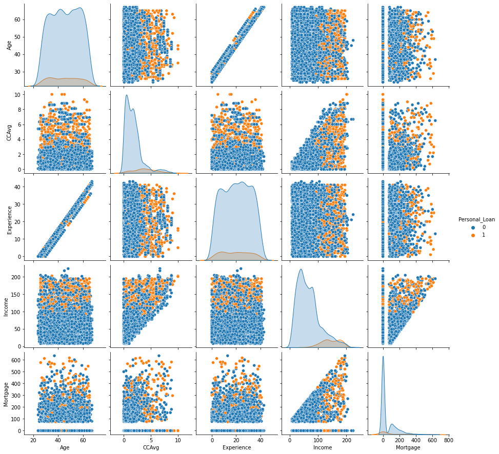

```python
#creating a pairplot

sns.pairplot(df[['Age','CCAvg','Experience','Income','Mortgage','Personal_Loan']], hue='Personal_Loan')
```

From bivariate analysis, we can conclude that:

1. Age and experience seem to correlate strongly
2. Those who accepted the loan are people who have higher income levels
3. Those who accepted the loan has somewhat higher CCAvg values

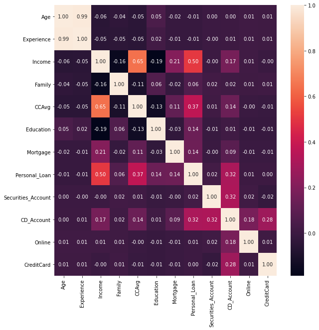

```python
#plotting heatmap for correlation between variables

plt.figure(figsize = (10,10))
sns.heatmap(df.corr(), annot = True, fmt =".2f")
```

From the heatmap, we can see that:

1. CCAvg somewhat correlates with Income.
2. It can be seen that age and experience correlate greatly, with a correlation value of 0.99. To prevent multicollinearity, we need to remove either one of the columns. As we have found that there are erroneous negative values for the experience column, we have decided to remove the experience column.
3. The target variable Personal_Loan is mostly correlated to Income, followed by CCAvg and then CD_Account.

```python
#removal of Experience column

df.drop('Experience',axis = 1,inplace=True)
```

```python
#removal of PLoanCat column

df.drop('PLoanCat',axis = 1,inplace=True)
```

```python
#checking of data

df.info()
```

```
<class 'pandas.core.frame.DataFrame'>
Int64Index: 4948 entries, 0 to 4999
Data columns (total 11 columns):
 #   Column              Non-Null Count  Dtype
---  ------              --------------  -----
 0   Age                 4948 non-null   int64
 1   Income              4948 non-null   int64
 2   Family              4948 non-null   int64
 3   CCAvg               4948 non-null   float64
 4   Education           4948 non-null   int64
 5   Mortgage            4948 non-null   int64
 6   Personal_Loan       4948 non-null   int64
 7   Securities_Account  4948 non-null   int64
 8   CD_Account          4948 non-null   int64
 9   Online              4948 non-null   int64
 10  CreditCard          4948 non-null   int64
dtypes: float64(1), int64(10)
memory usage: 463.9 KB
```

## Splitting of Data

```python
#defining x, independent variable, and y, dependent variable
x = df.drop('Personal_Loan', axis = 1)
y = df['Personal_Loan']

#setting training and testing data
x_train, x_test, y_train, y_test = train_test_split(x, y, test_size=0.30, random_state=1)
```

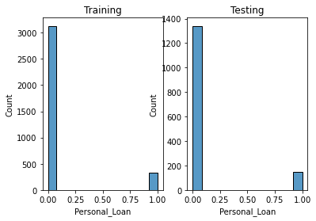

```python
#checking if training and testing data are balanced

fig, (ax1, ax2) = plt.subplots(1,2)
sns.histplot(y_train, ax=ax1); ax1.set_title('Training')
sns.histplot(y_test, ax=ax2); ax2.set_title('Testing')
```

```python
#checking the distribution of the data in training and testing set

print("{0:0.2f}% data is in training set".format((len(x_train)/len(df.index)) * 100))
print("{0:0.2f}% data is in test set".format((len(x_test)/len(df.index)) * 100))
```

```
69.99% data is in training set
30.01% data is in test set
```

```python
#checking the distribution of the target variable in training and testing set

print("Original Personal_Loan True Values    : {0} ({1:0.2f}%)".format(len(df.loc[df['Personal_Loan'] == 1]), (len(df.loc[df['Personal_Loan'] == 1])/len(df.index)) * 100))
print("Original Personal_Loan False Values   : {0} ({1:0.2f}%)".format(len(df.loc[df['Personal_Loan'] == 0]), (len(df.loc[df['Personal_Loan'] == 0])/len(df.index)) * 100))
print("")
print("Training Personal_Loan True Values    : {0} ({1:0.2f}%)".format(len(y_train[y_train[:] == 1]), (len(y_train[y_train[:] == 1])/len(y_train)) * 100))
print("Training Personal_Loan False Values   : {0} ({1:0.2f}%)".format(len(y_train[y_train[:] == 0]), (len(y_train[y_train[:] == 0])/len(y_train)) * 100))
print("")
print("Test Personal_Loan True Values        : {0} ({1:0.2f}%)".format(len(y_test[y_test[:] == 1]), (len(y_test[y_test[:] == 1])/len(y_test)) * 100))
print("Test Personal_Loan False Values       : {0} ({1:0.2f}%)".format(len(y_test[y_test[:] == 0]), (len(y_test[y_test[:] == 0])/len(y_test)) * 100))
print("")
```

```
Original Personal_Loan True Values    : 480 (9.70%)
Original Personal_Loan False Values   : 4468 (90.30%)

Training Personal_Loan True Values    : 335 (9.67%)
Training Personal_Loan False Values   : 3128 (90.33%)

Test Personal_Loan True Values        : 145 (9.76%)
Test Personal_Loan False Values       : 1340 (90.24%)
```

The percentages of the target variable Personal_Load are distributed well between the training and testing data.

## Logistic Regression

### Basic Logistic Regression Model

```python
#importing libraries for logistic regression
from sklearn import metrics
from sklearn.linear_model import LogisticRegression
from sklearn.metrics import accuracy_score,precision_score,recall_score,f1_score

#fitting the model using train data
model = LogisticRegression(solver="liblinear")
model.fit(x_train, y_train)

#predict on test
y_predict = model.predict(x_test)
```

```python
#finding model score/accuracy
model_score = model.score(x_test, y_test)
print(model_score)
```

```
0.9474747474747475
```

```python
#finding coefficients & intercept of the model
coef_df = pd.DataFrame(model.coef_)
coef_df['intercept'] = model.intercept_
print(coef_df)
```

```
          0         1         2         3         4         5         6  \
0 -0.016008  0.041973  0.436279  0.085207  1.175008  0.000627 -0.618295

          7         8         9  intercept
0  3.185728 -0.652137 -1.085441  -9.119753
```

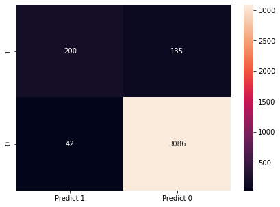

```python
#plotting a confusion matrix of the log regression model (y_train)

cm = metrics.confusion_matrix(y_train, model.predict(x_train), labels=[1, 0])

df_cm = pd.DataFrame(cm, index = [i for i in ["1","0"]],
                  columns = [i for i in ["Predict 1","Predict 0"]])
plt.figure(figsize = (7,5))
sns.heatmap(df_cm, annot=True, fmt='d')
```

From the confusion matrix above for training data, we can see that:

1. True positives : 200
2. False positives : 42
3. False negatives : 135
4. True negatives : 3086

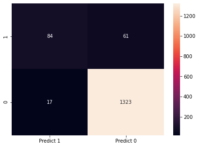

```python
#plotting a confusion matrix of the log regression model (y_test)

cm = metrics.confusion_matrix(y_test, y_predict, labels=[1, 0])

df_cm = pd.DataFrame(cm, index = [i for i in ["1","0"]],
                  columns = [i for i in ["Predict 1","Predict 0"]])
plt.figure(figsize = (7,5))
sns.heatmap(df_cm, annot=True, fmt='d')
```

From the confusion matrix above for test data, we can see that:

1. True positives : 84
2. False positives : 17
3. False negatives : 61
4. True negatives : 1323

```python
#function to calculate recall score
def get_recall_score(model):
    '''
    model : classifier to predict values of X

    '''
    pred_train = model.predict(x_train)
    pred_test = model.predict(x_test)
    print("Recall on training set : ",metrics.recall_score(y_train,pred_train))
    print("Recall on test set : ",metrics.recall_score(y_test,pred_test))
```

```python
#showing recall score for logistic regression model
get_recall_score(model)
```

```
Recall on training set :  0.5970149253731343
Recall on test set :  0.5793103448275863
```

```python
#showing accuracy on train & test
from sklearn.metrics import accuracy_score
print('Accuracy on train data:',accuracy_score(y_train, model.predict(x_train)) )
print('Accuracy on test data:',accuracy_score(y_test, y_predict))
```

```
Accuracy on train data: 0.9488882471845221
Accuracy on test data: 0.9474747474747475
```

```python
print('Precision:',precision_score(y_test, y_predict))
print('F1 score:',f1_score(y_test, y_predict))
```

```
Precision: 0.8316831683168316
F1 score: 0.6829268292682926
```

```python
#y_pred for train data
pred_train = model.predict(x_train)
```

```python
#probability of predicted class 0 & 1
y_predictprob = model.predict_proba(x_test)
```

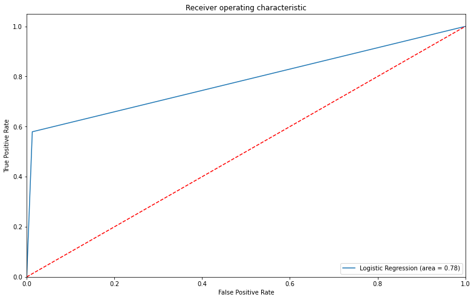

```python
#creation of ROC curve, while finding AUC
from sklearn.metrics import roc_auc_score
from sklearn.metrics import roc_curve

def plot_roc_auc(y_test, y_predict):
    logit_roc_auc = roc_auc_score(y_test, y_predict)
    fpr, tpr, thresholds = roc_curve(y_test, y_predict)
    plt.figure(figsize=(13,8))
    plt.plot(fpr, tpr, label='Logistic Regression (area = %0.2f)' % logit_roc_auc)
    plt.plot([0, 1], [0, 1],'r--')
    plt.xlim([0.0, 1.0])
    plt.ylim([0.0, 1.05])
    plt.xlabel('False Positive Rate')
    plt.ylabel('True Positive Rate')
    plt.title('Receiver operating characteristic')
    plt.legend(loc="lower right")
    plt.show()

plot_roc_auc(y_test, y_predict)
```

```python
#tabulating probability
prob = pd.DataFrame(list(zip(y_predict,y_predictprob[:, 1])), columns=['Predicted Class','Probability'])
prob
```

|  | Predicted Class | Probability |
| --- | --- | --- |
| 0 | 0 | 0.001383 |
| 1 | 0 | 0.183604 |
| 2 | 0 | 0.048236 |
| 3 | 0 | 0.000435 |
| 4 | 0 | 0.010299 |
| ... | ... | ... |
| 1480 | 0 | 0.031246 |
| 1481 | 0 | 0.002278 |
| 1482 | 0 | 0.007933 |
| 1483 | 0 | 0.107080 |
| 1484 | 0 | 0.014843 |

1485 rows × 2 columns

```python
#seems that the default cutoff is probability > 0.5 to be classified as class 1
prob[prob['Predicted Class'] == 1]
```

|  | Predicted Class | Probability |
| --- | --- | --- |
| 52 | 1 | 0.617344 |
| 53 | 1 | 0.804827 |
| 55 | 1 | 0.776730 |
| 69 | 1 | 0.763279 |
| 72 | 1 | 0.935100 |
| ... | ... | ... |
| 1425 | 1 | 0.623449 |
| 1427 | 1 | 0.513851 |
| 1429 | 1 | 0.861294 |
| 1436 | 1 | 0.751169 |
| 1476 | 1 | 0.789553 |

101 rows × 2 columns

### Logistic Regression Model Improvement with Adjustments to Threshold Value (AUC & ROC)

```python
#the optimal threshold cut off would be where tpr is high and fpr is low
fpr, tpr, thresholds = roc_curve(y_test, y_predictprob[:, 1])

optimal_idx = np.argmax(tpr - fpr)
optimal_threshold = thresholds[optimal_idx]
print('The optimal threshold is : ',optimal_threshold)
```

```
The optimal threshold is :  0.08525716074590448
```

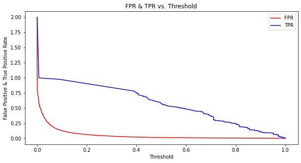

```python
plt.figure(figsize=(10,5))
FPR = plt.plot(fpr, thresholds, color='red', label='FPR')
TPR = plt.plot(tpr, thresholds, color='blue', label='TPR')
plt.xlabel('Threshold')
plt.ylabel('False Positive & True Positive Rate')
plt.title('FPR & TPR vs. Threshold')
plt.legend()
plt.show()
```

```python
#saving optimized y_predict, where class = 1 when prob > optimal threshold, and class = 0 when prob < optimal threshold
y_predict_opt = (y_predictprob[:, 1] > optimal_threshold).astype(int)
```

```python
#checking on performance
print('Accuracy:',accuracy_score(y_test, y_predict_opt))
print('Recall:',recall_score(y_test, y_predict_opt))
print('Precision:',precision_score(y_test, y_predict_opt))
print('F1 score:',f1_score(y_test, y_predict_opt))
```

```
Accuracy: 0.8626262626262626
Recall: 0.9448275862068966
Precision: 0.4114114114114114
F1 score: 0.5732217573221757
```

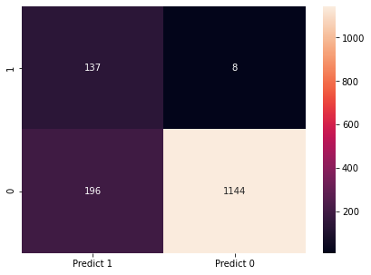

```python
#plotting a confusion matrix of the updated

cm = metrics.confusion_matrix(y_test, y_predict_opt, labels=[1, 0])

df_cm = pd.DataFrame(cm, index = [i for i in ["1","0"]],
                  columns = [i for i in ["Predict 1","Predict 0"]])
plt.figure(figsize = (7,5))
sns.heatmap(df_cm, annot=True, fmt='d')
```

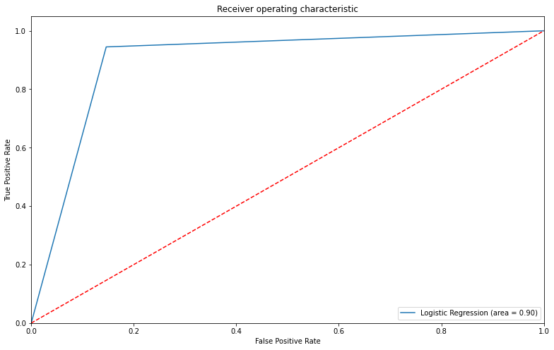

```python
plot_roc_auc(y_test, y_predict_opt)
```

After adjusting the threshold to 0.08525716074590448 , it can be seen that recall and AUC improved significantly, as shown from the confusion matrix as well (very little amount of false negatives). Recall is an important parameter to be used in this case, as if there are too many false negatives, there will be missed opportunities to convert more asset customers, which is the main goal of management.

### Logistic Regression Model using Statsmodel

```python
#log regression using statsmodel

#tabulate scaled features
x_train2 = pd.DataFrame(x_train, index=y_train.index, columns=x_train.columns)
x_test2 = pd.DataFrame(x_test, index=y_test.index, columns=x_train.columns)
```

```python
import statsmodels.api as sm

# adding constant to training and test set
x_train2 = sm.add_constant(x_train2)
x_test2 = sm.add_constant(x_test2)

logit = sm.Logit(y_train, x_train2)

lg = logit.fit()

print(lg.summary2())

# Let's Look at Model Performance
pred_train2 = lg.predict(x_train2)
pred_train2 = list(map(round, pred_train2))

y_pred2 = lg.predict(x_test2)
y_pred2 = list(map(round, y_pred2))

print('recall on train data:',recall_score(y_train, pred_train2) )
print('recall on test data:',recall_score(y_test, y_pred2))
```

```
Optimization terminated successfully.
         Current function value: 0.129774
         Iterations 9
                            Results: Logit
======================================================================
Model:                Logit             Pseudo R-squared:  0.592
Dependent Variable:   Personal_Loan     AIC:               920.8125
Date:                 2021-06-11 15:53  BIC:               988.4613
No. Observations:     3463              Log-Likelihood:    -449.41
Df Model:             10                LL-Null:           -1100.7
Df Residuals:         3452              LLR p-value:       1.0297e-273
Converged:            1.0000            Scale:             1.0000
No. Iterations:       9.0000
----------------------------------------------------------------------
                    Coef.   Std.Err.    z     P>|z|   [0.025   0.975]
----------------------------------------------------------------------
const              -13.4002   0.7931 -16.8970 0.0000 -14.9546 -11.8459
Age                  0.0088   0.0079   1.1111 0.2665  -0.0067   0.0243
Income               0.0539   0.0031  17.1548 0.0000   0.0478   0.0601
Family               0.6728   0.0889   7.5686 0.0000   0.4985   0.8470
CCAvg                0.1200   0.0478   2.5131 0.0120   0.0264   0.2136
Education            1.6457   0.1344  12.2485 0.0000   1.3823   1.9090
Mortgage             0.0009   0.0006   1.3551 0.1754  -0.0004   0.0022
Securities_Account  -0.8235   0.3437  -2.3962 0.0166  -1.4972  -0.1499
CD_Account           3.9352   0.3995   9.8504 0.0000   3.1522   4.7181
Online              -0.6946   0.1866  -3.7222 0.0002  -1.0603  -0.3289
CreditCard          -1.2879   0.2498  -5.1561 0.0000  -1.7774  -0.7983
======================================================================

recall on train data: 0.6358208955223881
recall on test data: 0.6551724137931034
```

```python
#Check and treat multicollinearity
from statsmodels.stats.outliers_influence import variance_inflation_factor
vif_series1 = pd.Series([variance_inflation_factor(x_train2.values,i) for i in range(x_train2.shape[1])],index=x_train2.columns)
print('Series before feature selection: \n\n{}\n'.format(vif_series1))
```

```
Series before feature selection:

const                 35.535916
Age                    1.010260
Income                 1.898579
Family                 1.026779
CCAvg                  1.774076
Education              1.045194
Mortgage               1.050018
Securities_Account     1.137029
CD_Account             1.313485
Online                 1.036537
CreditCard             1.104009
dtype: float64
```

From the values above, we can see that there are no multicollinearity (high amount of multicollinearity is shown with the value > 5).

Both Age and Mortgage has P value > 0.05, so we will drop the columns and see if the model improves.

```python
#Age has highest p values among those with p-value greater than 0.05, hence we will try to drop it
x_train3 = x_train2.drop('Age', axis =1)
x_test3 = x_test2.drop('Age',axis =1)

logit1 = sm.Logit(y_train, x_train3 )
lg1 = logit1.fit()
print(lg1.summary2())

# Let's Look at Model Performance
pred_train3 = lg1.predict(x_train3)
pred_train3 = list(map(round, pred_train3))

y_pred3 = lg1.predict(x_test3)
y_pred3 = list(map(round, y_pred3))

print('Recall on train data:',recall_score(y_train, pred_train3) )
print('Recall on test data:',recall_score(y_test, y_pred3))
```

```
Optimization terminated successfully.
         Current function value: 0.129952
         Iterations 9
                            Results: Logit
======================================================================
Model:                Logit             Pseudo R-squared:  0.591
Dependent Variable:   Personal_Loan     AIC:               920.0493
Date:                 2021-06-11 15:53  BIC:               981.5482
No. Observations:     3463              Log-Likelihood:    -450.02
Df Model:             9                 LL-Null:           -1100.7
Df Residuals:         3453              LLR p-value:       1.5387e-274
Converged:            1.0000            Scale:             1.0000
No. Iterations:       9.0000
----------------------------------------------------------------------
                    Coef.   Std.Err.    z     P>|z|   [0.025   0.975]
----------------------------------------------------------------------
const              -12.9336   0.6606 -19.5781 0.0000 -14.2283 -11.6388
Income               0.0537   0.0031  17.1636 0.0000   0.0475   0.0598
Family               0.6667   0.0888   7.5073 0.0000   0.4927   0.8408
CCAvg                0.1139   0.0476   2.3933 0.0167   0.0206   0.2072
Education            1.6402   0.1339  12.2466 0.0000   1.3777   1.9027
Mortgage             0.0009   0.0007   1.3566 0.1749  -0.0004   0.0022
Securities_Account  -0.8223   0.3433  -2.3953 0.0166  -1.4952  -0.1495
CD_Account           3.9431   0.3994   9.8719 0.0000   3.1602   4.7260
Online              -0.6912   0.1864  -3.7075 0.0002  -1.0566  -0.3258
CreditCard          -1.2844   0.2499  -5.1401 0.0000  -1.7742  -0.7947
======================================================================

Recall on train data: 0.6268656716417911
Recall on test data: 0.6551724137931034
```

There isn't any significant improvement after removal of Age column. Let's try with Mortgage.

```python
#Dropping Mortgage with P value > 0.05
x_train4 = x_train3.drop('Mortgage', axis =1)
x_test4 = x_test3.drop('Mortgage',axis =1)

logit2 = sm.Logit(y_train, x_train4 )
lg2 = logit2.fit()
print(lg2.summary2())

# Let's Look at Model Performance
pred_train4 = lg2.predict(x_train4)
pred_train4 = list(map(round, pred_train4))

y_pred4 = lg2.predict(x_test4)
y_pred4 = list(map(round, y_pred4))

print('Recall on train data:',recall_score(y_train, pred_train4) )
print('Recall on test data:',recall_score(y_test, y_pred4))
```

```
Optimization terminated successfully.
         Current function value: 0.130216
         Iterations 9
                            Results: Logit
======================================================================
Model:                Logit             Pseudo R-squared:  0.590
Dependent Variable:   Personal_Loan     AIC:               919.8768
Date:                 2021-06-11 15:53  BIC:               975.2258
No. Observations:     3463              Log-Likelihood:    -450.94
Df Model:             8                 LL-Null:           -1100.7
Df Residuals:         3454              LLR p-value:       2.9016e-275
Converged:            1.0000            Scale:             1.0000
No. Iterations:       9.0000
----------------------------------------------------------------------
                    Coef.   Std.Err.    z     P>|z|   [0.025   0.975]
----------------------------------------------------------------------
const              -12.8715   0.6567 -19.5997 0.0000 -14.1587 -11.5844
Income               0.0542   0.0031  17.4012 0.0000   0.0481   0.0603
Family               0.6706   0.0890   7.5366 0.0000   0.4962   0.8450
CCAvg                0.1041   0.0470   2.2143 0.0268   0.0120   0.1963
Education            1.6262   0.1329  12.2319 0.0000   1.3656   1.8868
Securities_Account  -0.8291   0.3444  -2.4073 0.0161  -1.5041  -0.1541
CD_Account           3.9668   0.4002   9.9117 0.0000   3.1824   4.7512
Online              -0.6909   0.1862  -3.7108 0.0002  -1.0559  -0.3260
CreditCard          -1.2987   0.2499  -5.1978 0.0000  -1.7885  -0.8090
======================================================================

Recall on train data: 0.6268656716417911
Recall on test data: 0.6758620689655173
```

After removal of Mortgage column, we can see that the recall on test data improved a bit.

### Comparison of Logistic Regression Models

```python
comparison = pd.DataFrame({'Model':['Initial log regression model', 'Log regression with threshold value adjustment',
                                          'Log regression with statsmodel'],  'Test_Recall':[0.58,0.95,0.68]})
comparison
```

|  | Model | Test_Recall |
| --- | --- | --- |
| 0 | Initial log regression model | 0.58 |
| 1 | Log regression with threshold value adjustment | 0.95 |
| 2 | Log regression with statsmodel | 0.68 |

Hence, we can conclude that logistic regression model with threshold value adjustment is the most ideal model that can be used.